# Course 8 Project

2022-09-08

# Machine Learning Final Project

[output not shown]

[output not shown]

[output not shown]

[output not shown]

[output not shown]

## Summary

Using devices such as Jawbone Up, Nike FuelBand, and Fitbit it is now possible to collect a large amount of data about personal activity relatively inexpensively. These type of devices are part of the quantified self movement – a group of enthusiasts who take measurements about themselves regularly to improve their health, to find patterns in their behavior, or because they are tech geeks. One thing that people regularly do is quantify how much of a particular activity they do, but they rarely quantify how well they do it. In this project, your goal will be to use data from accelerometers on the belt, forearm, arm, and dumbell of 6 participants.

## Inputting and Cleaning Data

```r
training_raw <- read_csv("/Users/isabellademo/Downloads/pml-training.csv")
training_raw <- training_raw[, -c(1)]

testing_raw <- read_csv("/Users/isabellademo/Downloads/pml-testing.csv")
```

```
## ──────────────────────────────────────────────────────── Delimiter: "," chr
## (3): user_name, cvtd_timestamp, new_window dbl (57): ...1,
## raw_timestamp_part_1, raw_timestamp_part_2, num_window, rol... lgl (100):
## kurtosis_roll_belt, kurtosis_picth_belt, kurtosis_yaw_belt, skewn...
```

```r
testing_raw <- testing_raw[, -c(1)]

valid <- read_csv("/Users/isabellademo/Downloads/pml-testing.csv")
```

```
## ──────────────────────────────────────────────────────── Delimiter: "," chr
## (3): user_name, cvtd_timestamp, new_window dbl (57): ...1,
## raw_timestamp_part_1, raw_timestamp_part_2, num_window, rol... lgl (100):
## kurtosis_roll_belt, kurtosis_picth_belt, kurtosis_yaw_belt, skewn...
```

### Cleaning out the missing values

```r
valid_in <- valid[, colSums(is.na(valid)) == 0]
train_in <- training_raw[, colSums(is.na(training_raw)) == 0]
test_in <- testing_raw[, colSums(is.na(testing_raw)) == 0]
```

Take out the irrelevant variables:

```r
train_in <- train_in[,-c(1:6)]
test_in <- test_in[,-c(1:6)]
```

### Creating Training and Test sets

```r
set.seed(1234)
inTrain <- createDataPartition(train_in$classe, p = 0.7, list = FALSE)
training <- train_in[inTrain, ]
testing <- train_in[-inTrain, ]
dim(training)
```

```
## [1] 13737    53
```

### Exploratory Correlation Plot

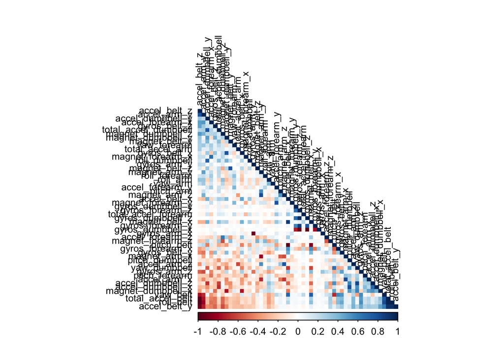

```r
cor_mat <- cor(training[, -53])
corrplot(cor_mat, order = "FPC", method = "color", type = "lower",
         tl.cex = 0.8, tl.col = rgb(0, 0, 0),mar = c(1, 1, 1, 1))
```

Looking for highly correlated variables:

```r
high_cor = findCorrelation(cor_mat, cutoff = 0.75)
names(training)[high_cor]
```

```
##  [1] "accel_belt_z"      "roll_belt"         "accel_belt_y"
##  [4] "total_accel_belt"  "accel_dumbbell_z"  "accel_belt_x"
##  [7] "pitch_belt"        "magnet_dumbbell_x" "accel_dumbbell_y"
## [10] "magnet_dumbbell_y" "accel_dumbbell_x"  "accel_arm_x"
## [13] "accel_arm_z"       "magnet_arm_y"      "magnet_belt_z"
## [16] "accel_forearm_y"   "gyros_forearm_y"   "gyros_dumbbell_x"
## [19] "gyros_dumbbell_z"  "gyros_arm_x"
```

## Model Testing

Testing three different models:  
1. Decision Trees  
2. Random Forests  
3. Generalized Boosted Model

Create the “fitControl” variable for cross-validation:

```r
fitControl <- trainControl(method="cv", number = 3)
```

### Decision Tree Model

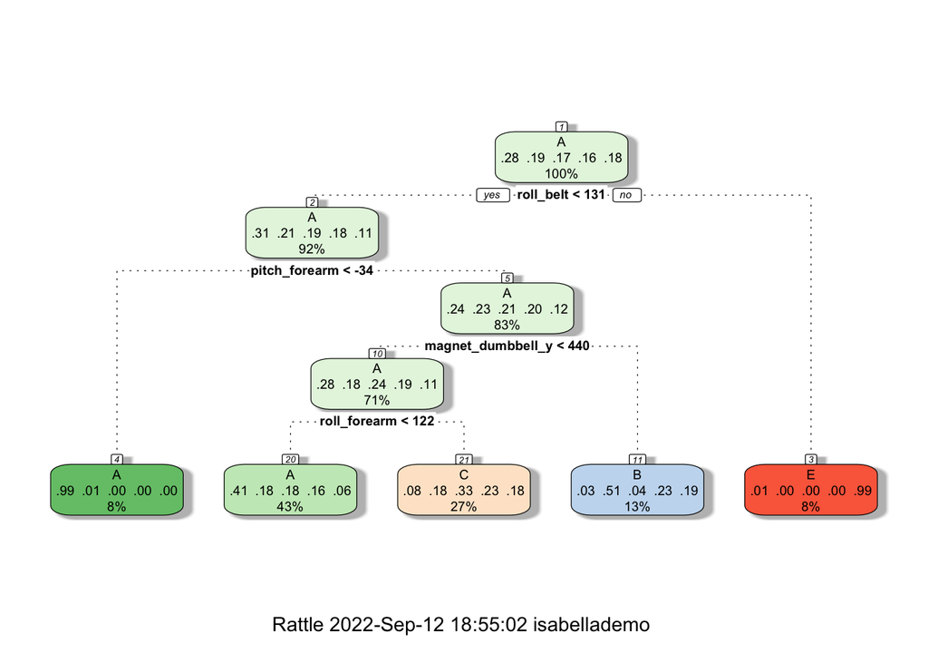

```r
modFit <- train(classe~., method = "rpart", data = training, trControl = fitControl)
fancyRpartPlot(modFit$finalModel)
```

Using confusionMatrix to find accuracy via testing data:

```r
rpart_predict <- predict(modFit,newdata = testing)
rpart_matrix <- confusionMatrix(rpart_predict, as.factor(testing$classe))
print(rpart_matrix)
```

```
## Confusion Matrix and Statistics
##
##           Reference
## Prediction    A    B    C    D    E
##          A 1519  473  484  451  156
##          B   28  401   45  167  148
##          C  123  265  497  346  289
##          D    0    0    0    0    0
##          E    4    0    0    0  489
##
## Overall Statistics
##
##                Accuracy : 0.4938
##                  95% CI : (0.4809, 0.5067)
##     No Information Rate : 0.2845
##     P-Value [Acc > NIR] : < 2.2e-16
##
##                   Kappa : 0.338
##
##  Mcnemar's Test P-Value : NA
##
## Statistics by Class:
##
##                      Class: A Class: B Class: C Class: D Class: E
## Sensitivity            0.9074  0.35206  0.48441   0.0000  0.45194
## Specificity            0.6286  0.91825  0.78946   1.0000  0.99917
## Pos Pred Value         0.4927  0.50824  0.32697      NaN  0.99189
## Neg Pred Value         0.9447  0.85518  0.87881   0.8362  0.89002
## Prevalence             0.2845  0.19354  0.17434   0.1638  0.18386
## Detection Rate         0.2581  0.06814  0.08445   0.0000  0.08309
## Detection Prevalence   0.5239  0.13407  0.25828   0.0000  0.08377
## Balanced Accuracy      0.7680  0.63516  0.63693   0.5000  0.72555
```

The accuracy is 0.49 and the out-of-sample error is around 0.51. This is a high out-of-sample error.

### Random Forest Model

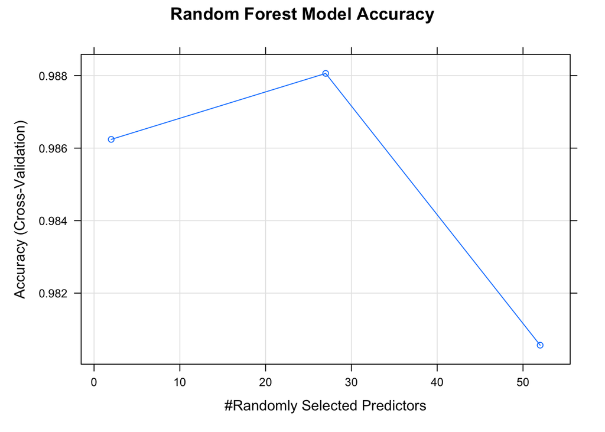

```r
rf_model <- train(classe~., data= training, method="rf", trControl=fitControl, verbose=FALSE)
plot(rf_model,main="Random Forest Model Accuracy")
```

Using confusionMatrix to find accuracy via testing data:

```r
rf_predict <- predict(rf_model, newdata = testing)
rf_matrix <- confusionMatrix(rf_predict, as.factor(testing$classe))
print(rf_matrix)
```

```
## Confusion Matrix and Statistics
##
##           Reference
## Prediction    A    B    C    D    E
##          A 1673    5    0    0    0
##          B    0 1130   13    0    0
##          C    1    4 1011    8    0
##          D    0    0    2  955    0
##          E    0    0    0    1 1082
##
## Overall Statistics
##
##                Accuracy : 0.9942
##                  95% CI : (0.9919, 0.996)
##     No Information Rate : 0.2845
##     P-Value [Acc > NIR] : < 2.2e-16
##
##                   Kappa : 0.9927
##
##  Mcnemar's Test P-Value : NA
##
## Statistics by Class:
##
##                      Class: A Class: B Class: C Class: D Class: E
## Sensitivity            0.9994   0.9921   0.9854   0.9907   1.0000
## Specificity            0.9988   0.9973   0.9973   0.9996   0.9998
## Pos Pred Value         0.9970   0.9886   0.9873   0.9979   0.9991
## Neg Pred Value         0.9998   0.9981   0.9969   0.9982   1.0000
## Prevalence             0.2845   0.1935   0.1743   0.1638   0.1839
## Detection Rate         0.2843   0.1920   0.1718   0.1623   0.1839
## Detection Prevalence   0.2851   0.1942   0.1740   0.1626   0.1840
## Balanced Accuracy      0.9991   0.9947   0.9914   0.9951   0.9999
```

### GBM Model

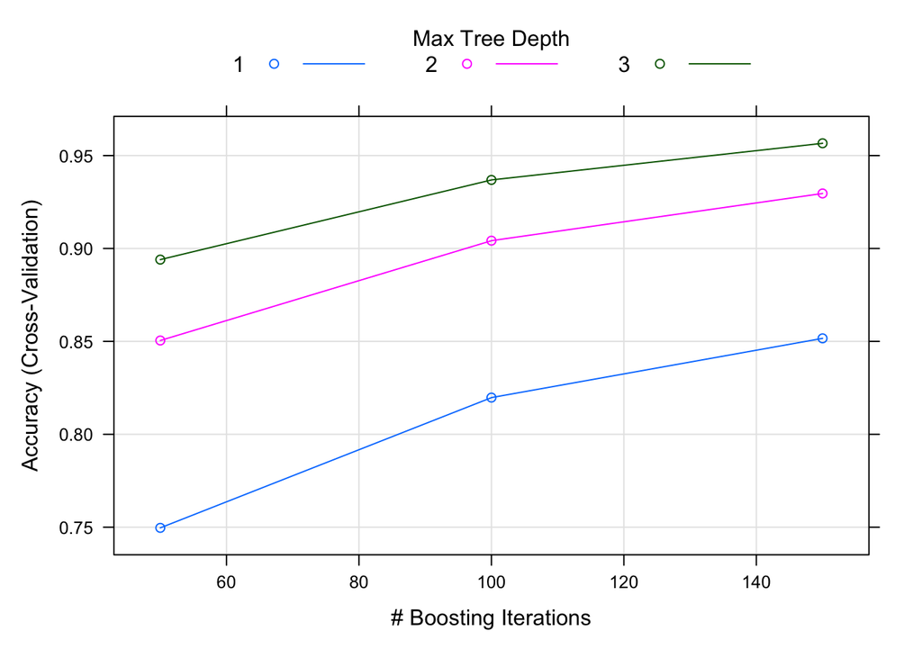

```r
gbm_model <- train(classe~., data= training, method="gbm", trControl=fitControl, verbose=FALSE)
plot(gbm_model)
```

Using confusionMatrix to find accuracy via testing data:

```r
gbm_predict <- predict(gbm_model, newdata = testing)
gbm_matrix <- confusionMatrix(gbm_predict, as.factor(testing$classe))
print(gbm_matrix)
```

```
## Confusion Matrix and Statistics
##
##           Reference
## Prediction    A    B    C    D    E
##          A 1650   30    0    2    2
##          B   15 1083   32    2    9
##          C    6   26  979   29    9
##          D    1    0   14  926    9
##          E    2    0    1    5 1053
##
## Overall Statistics
##
##                Accuracy : 0.967
##                  95% CI : (0.9622, 0.9714)
##     No Information Rate : 0.2845
##     P-Value [Acc > NIR] : < 2.2e-16
##
##                   Kappa : 0.9583
##
##  Mcnemar's Test P-Value : 9.368e-05
##
## Statistics by Class:
##
##                      Class: A Class: B Class: C Class: D Class: E
## Sensitivity            0.9857   0.9508   0.9542   0.9606   0.9732
## Specificity            0.9919   0.9878   0.9856   0.9951   0.9983
## Pos Pred Value         0.9798   0.9492   0.9333   0.9747   0.9925
## Neg Pred Value         0.9943   0.9882   0.9903   0.9923   0.9940
## Prevalence             0.2845   0.1935   0.1743   0.1638   0.1839
## Detection Rate         0.2804   0.1840   0.1664   0.1573   0.1789
## Detection Prevalence   0.2862   0.1939   0.1782   0.1614   0.1803
## Balanced Accuracy      0.9888   0.9693   0.9699   0.9779   0.9858
```

The accuracy of the GBM model is around 0.97 and the out-of-sample error is around 0.03.

## Best Model and Conclusions

The Random Forest model has the best accuracy and lowest out-of-sample error. We will now take the random forest model and apply it to the validation data.

```r
final_results <- predict(rf_model, newdata = valid_in)
print(final_results)
```

```
##  [1] B A B A A E D B A A B C B A E E A B B B
## Levels: A B C D E
```

The results are the predicted classe outcomes for the next 20 numbers.